# T4

### TCX3212 Predictive Analytics

### Tutorial/Lab 4

Learning Objectives

- Perform linear regression analysis using Python
- 2025 Samantha Sow Jin Sze. National University of Singapore. Unauthorized reproduction or distribution is prohibited.

#### Setup

```python
# In JupyterLab, first navigate to the directory containing College.csv
# import os

# os.chdir("C:/")  # Replace with your actual path
```

a) There are some missing values in the csv file (denoted using the "?" character). Read the help pages for read_csv to see how to convert the missing values to be NA and ignore these values in the analysis.

```python
import pandas as pd

auto_data = pd.read_csv("Auto.csv", na_values="?", comment="\t", skipinitialspace=True)

# Optionally drop missing rows
auto_data = auto_data.dropna()
```

```python
# View the dataframe (equivalent to View())
print(auto_data.info())
auto_data
```

```
<class 'pandas.core.frame.DataFrame'>
Index: 392 entries, 0 to 396
Data columns (total 8 columns):
 #   Column        Non-Null Count  Dtype
---  ------        --------------  -----
 0   mpg           392 non-null    float64
 1   cylinders     392 non-null    int64
 2   displacement  392 non-null    float64
 3   horsepower    392 non-null    float64
 4   weight        392 non-null    int64
 5   acceleration  392 non-null    float64
 6   year          392 non-null    int64
 7   name          392 non-null    object
dtypes: float64(4), int64(3), object(1)
memory usage: 27.6+ KB
None
```

|  | mpg | cylinders | displacement | horsepower | weight | acceleration | year | name |
| --- | --- | --- | --- | --- | --- | --- | --- | --- |
| 0 | 19.0 | 3 | 70.0 | 97.0 | 2330 | 13.5 | 72 | mazda rx2 coupe |
| 1 | 18.0 | 3 | 70.0 | 90.0 | 2124 | 13.5 | 73 | maxda rx3 |
| 2 | 21.5 | 3 | 80.0 | 110.0 | 2720 | 13.5 | 77 | mazda rx-4 |
| 3 | 23.7 | 3 | 70.0 | 100.0 | 2420 | 12.5 | 80 | mazda rx-7 gs |
| 4 | 24.0 | 4 | 113.0 | 95.0 | 2372 | 15.0 | 70 | toyota corona mark ii |
| ... | ... | ... | ... | ... | ... | ... | ... | ... |
| 392 | 19.2 | 8 | 267.0 | 125.0 | 3605 | 15.0 | 79 | chevrolet malibu classic (sw) |
| 393 | 18.5 | 8 | 360.0 | 150.0 | 3940 | 13.0 | 79 | chrysler lebaron town @ country (sw) |
| 394 | 23.0 | 8 | 350.0 | 125.0 | 3900 | 17.4 | 79 | cadillac eldorado |
| 395 | 23.9 | 8 | 260.0 | 90.0 | 3420 | 22.2 | 79 | oldsmobile cutlass salon brougham |
| 396 | 26.6 | 8 | 350.0 | 105.0 | 3725 | 19.0 | 81 | oldsmobile cutlass ls |

392 rows × 8 columns

b) Use the statsmodels.formula.api module to fit a simple linear regression using mpg as the response and horsepower as the predictor. Use the summary() function to print the results of the model. Comment on the output.

```python
import statsmodels.formula.api as smf

model = smf.ols("mpg ~ horsepower", data=auto_data).fit()

print(model.summary())
```

```
                            OLS Regression Results
==============================================================================
Dep. Variable:                    mpg   R-squared:                       0.606
Model:                            OLS   Adj. R-squared:                  0.605
Method:                 Least Squares   F-statistic:                     599.7
Date:                Mon, 16 Feb 2026   Prob (F-statistic):           7.03e-81
Time:                        18:21:46   Log-Likelihood:                -1178.7
No. Observations:                 392   AIC:                             2361.
Df Residuals:                     390   BIC:                             2369.
Df Model:                           1
Covariance Type:            nonrobust
==============================================================================
                 coef    std err          t      P>|t|      [0.025      0.975]
------------------------------------------------------------------------------
Intercept     39.9359      0.717     55.660      0.000      38.525      41.347
horsepower    -0.1578      0.006    -24.489      0.000      -0.171      -0.145
==============================================================================
Omnibus:                       16.432   Durbin-Watson:                   0.873
Prob(Omnibus):                  0.000   Jarque-Bera (JB):               17.305
Skew:                           0.492   Prob(JB):                     0.000175
Kurtosis:                       3.299   Cond. No.                         322.
==============================================================================

Notes:
[1] Standard Errors assume that the covariance matrix of the errors is correctly specified.
```

c) Write out the model in equation form. What does the coefficient for the horsepower variable suggest?

```python
# c) Model Equation and Interpretation

# Extract coefficients
intercept = model.params["Intercept"]
coef_horsepower = model.params["horsepower"]

print("Model Equation:")
print(f"mpg = {intercept:.4f} + ({coef_horsepower:.4f}) horsepower")
```

```
Model Equation:
mpg = 39.9359 + (-0.1578) horsepower
```

Interpretation of the horsepower coefficient:

- The coefficient for horsepower is -0.1578.
- This means that for every 1-unit increase in horsepower, the miles per gallon (mpg) decreases by approximately 0.1578 units.

Since the coefficient is negative, this indicates an inverse relationship:

- cars with higher horsepower tend to have lower fuel efficiency (lower mpg).

d) Comment on the quality of fit of the model.

Quality of Fit Metrics:

- R-squared: 0.6059
- Adjusted R-squared: 0.6049
- Root Mean Squared Error (RMSE): 4.9058

Interpretation:

- R² = 0.6059 means that approximately 60.59% of the variance in mpg is explained by horsepower.
- This suggests a moderate to strong relationship between horsepower and mpg.

e) Is there a statistically significant association between the predictor and the response?

```python
# e) Statistical Significance Test
print("Statistical Significance:")
print(f"P-value for horsepower: {model.pvalues['horsepower']:.4e}")
print(f"t-statistic: {model.tvalues['horsepower']:.4f}")
```

```
Statistical Significance:
P-value for horsepower: 7.0320e-81
t-statistic: -24.4891
```

Conclusion: There IS a statistically significant association between horsepower and mpg (p < 0.05) at 5% level of significance. We reject the null hypothesis that the coefficient is zero.

f) What is the predicted mpg associated with a horsepower of 98? What are the associated 95% confidence and prediction intervals? Explain the conceptual difference between these two intervals. Which one would a consumer use to estimate the fuel economy of a single specific car? Why?

```python
# f) Prediction with Confidence and Prediction Intervals

# Point prediction
prediction = model.predict({"horsepower": 98})
print(prediction)

# 95% Confidence Interval (for the mean response)
pred_summary = model.get_prediction(pd.DataFrame({"horsepower": [98]})).summary_frame(
    alpha=0.05
)
print(pred_summary)
```

```
0    24.467077
dtype: float64
        mean   mean_se  mean_ci_lower  mean_ci_upper  obs_ci_lower  \
0  24.467077  0.251262      23.973079      24.961075     14.809396

   obs_ci_upper
0     34.124758
```

Conceptual Difference:

- Confidence Interval: estimates the average mpg for ALL cars with 98 horsepower
- Prediction Interval: estimates mpg for a SINGLE SPECIFIC car with 98 horsepower

Consumer Use: A consumer should use the PREDICTION INTERVAL because:

- They want to estimate fuel economy for one specific car they might buy
- Prediction intervals are wider as they account for individual variation
- This provides a more realistic range for a single vehicle

g) Create a scatter plot of the response (y-axis) versus the predictor (x-axis) and overlay a regression line using seaborn; you may use matplotlib to customize the plot if needed.

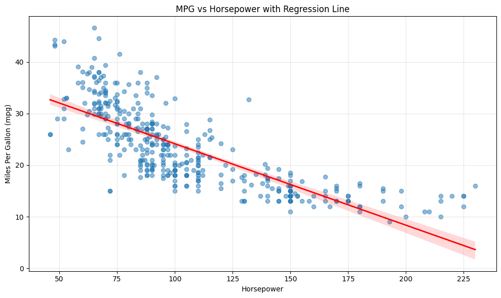

```python
# g) Scatter plot with regression line
import seaborn as sns
import matplotlib.pyplot as plt

plt.figure(figsize=(10, 6))
sns.regplot(
    x="horsepower",
    y="mpg",
    data=auto_data,
    scatter_kws={"alpha": 0.5},
    line_kws={"color": "red", "linewidth": 2},
)

plt.xlabel("Horsepower")
plt.ylabel("Miles Per Gallon (mpg)")
plt.title("MPG vs Horsepower with Regression Line")
plt.grid(alpha=0.3)
plt.tight_layout()
plt.show()
```

h) By looking at the scatter plot, it appears that the relationship between the predictor and the response is not linear. Produce diagnostic plot for the regression fit. Do the residuals versus fitted plot suggest that a linear fit is appropriate?

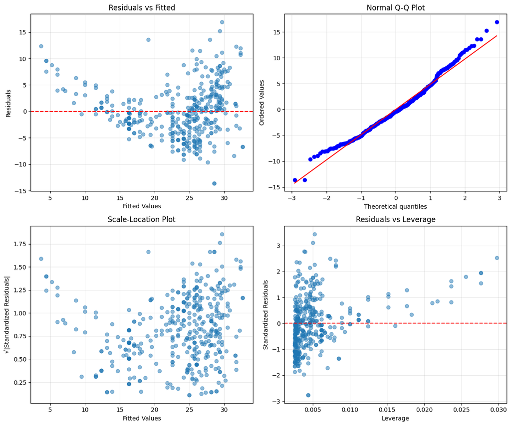

```
Interpretation of Residuals vs Fitted Plot:
The residuals show a clear curved pattern (U-shape),
suggesting that a linear fit is NOT appropriate.
The relationship appears to be non-linear (possibly quadratic).
```

```python
# h) Diagnostic Plots
import matplotlib.pyplot as plt
import numpy as np

fig, axes = plt.subplots(2, 2, figsize=(12, 10))

# 1. Residuals vs Fitted
axes[0, 0].scatter(model.fittedvalues, model.resid, alpha=0.5)
axes[0, 0].axhline(y=0, color="red", linestyle="--")
axes[0, 0].set_xlabel("Fitted Values")
axes[0, 0].set_ylabel("Residuals")
axes[0, 0].set_title("Residuals vs Fitted")
axes[0, 0].grid(alpha=0.3)

# 2. Q-Q Plot
from scipy import stats

stats.probplot(model.resid, dist="norm", plot=axes[0, 1])
axes[0, 1].set_title("Normal Q-Q Plot")
axes[0, 1].grid(alpha=0.3)

# 3. Scale-Location Plot
standardized_resid = np.sqrt(np.abs(model.resid_pearson))
axes[1, 0].scatter(model.fittedvalues, standardized_resid, alpha=0.5)
axes[1, 0].set_xlabel("Fitted Values")
axes[1, 0].set_ylabel("√|Standardized Residuals|")
axes[1, 0].set_title("Scale-Location Plot")
axes[1, 0].grid(alpha=0.3)

# 4. Residuals vs Leverage
from statsmodels.stats.outliers_influence import OLSInfluence

influence = OLSInfluence(model)
leverage = influence.hat_matrix_diag
axes[1, 1].scatter(leverage, model.resid_pearson, alpha=0.5)
axes[1, 1].axhline(y=0, color="red", linestyle="--")
axes[1, 1].set_xlabel("Leverage")
axes[1, 1].set_ylabel("Standardized Residuals")
axes[1, 1].set_title("Residuals vs Leverage")
axes[1, 1].grid(alpha=0.3)

plt.tight_layout()
plt.show()

print("\nInterpretation of Residuals vs Fitted Plot:")
print("The residuals show a clear curved pattern (U-shape),")
print("suggesting that a linear fit is NOT appropriate.")
print("The relationship appears to be non-linear (possibly quadratic).")
```

i) In some cases, the true relationship between the response and the predictors may be nonlinear. One simple way to extend the linear model is to accommodate a transformed predictor. The data seem to have a quadratic pattern, suggesting a model of the form (refer to notes)

To implement this in statsmodels.formula.api, apply a transformation to the predictor and wrap within the I( )function (e.g. I(predictor^2)) and treat it like a normal predictor variable. Generate a new model (model2) and interpret whether including the squared term improves the fit.

```python
# i) Quadratic Model
model2 = smf.ols("mpg ~ horsepower + I(horsepower**2)", data=auto_data).fit()

print(model2.summary())
print()
print("Comparison of Models:")
print(f"Model 1 (Linear) R²: {model.rsquared:.4f}")
print(f"Model 2 (Quadratic) R²: {model2.rsquared:.4f}")
print(f"Improvement in R²: {model2.rsquared - model.rsquared:.4f}")
print()
print("Interpretation:")
print("Including the squared term (horsepower²) improves the fit significantly.")
print(f"The R² increased from {model.rsquared:.4f} to {model2.rsquared:.4f},")
print("indicating that the quadratic model explains more variance in mpg.")
print("The squared term coefficient is statistically significant (check p-value).")
```

```
                            OLS Regression Results
==============================================================================
Dep. Variable:                    mpg   R-squared:                       0.688
Model:                            OLS   Adj. R-squared:                  0.686
Method:                 Least Squares   F-statistic:                     428.0
Date:                Mon, 16 Feb 2026   Prob (F-statistic):           5.40e-99
Time:                        18:21:46   Log-Likelihood:                -1133.2
No. Observations:                 392   AIC:                             2272.
Df Residuals:                     389   BIC:                             2284.
Df Model:                           2
Covariance Type:            nonrobust
======================================================================================
                         coef    std err          t      P>|t|      [0.025      0.975]
--------------------------------------------------------------------------------------
Intercept             56.9001      1.800     31.604      0.000      53.360      60.440
horsepower            -0.4662      0.031    -14.978      0.000      -0.527      -0.405
I(horsepower ** 2)     0.0012      0.000     10.080      0.000       0.001       0.001
==============================================================================
Omnibus:                       16.158   Durbin-Watson:                   1.090
Prob(Omnibus):                  0.000   Jarque-Bera (JB):               30.662
Skew:                           0.218   Prob(JB):                     2.20e-07
Kurtosis:                       4.299   Cond. No.                     1.29e+05
==============================================================================

Notes:
[1] Standard Errors assume that the covariance matrix of the errors is correctly specified.
[2] The condition number is large, 1.29e+05. This might indicate that there are
strong multicollinearity or other numerical problems.

Comparison of Models:
Model 1 (Linear) R²: 0.6059
Model 2 (Quadratic) R²: 0.6876
Improvement in R²: 0.0816

Interpretation:
Including the squared term (horsepower²) improves the fit significantly.
The R² increased from 0.6059 to 0.6876,
indicating that the quadratic model explains more variance in mpg.
The squared term coefficient is statistically significant (check p-value).
```

j) Generate diagnostic plot for model2 and examine the residuals versus fitted plot. What is the difference you see now? How about the results from summary()?

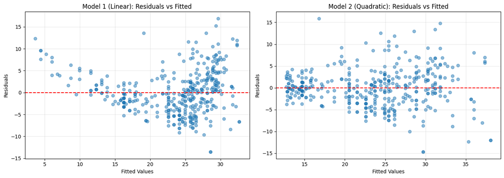

```
Difference in Residuals vs Fitted Plots:
Model 1 (Linear):
  - Shows clear curved pattern (U-shape)
  - Indicates systematic bias in predictions

Model 2 (Quadratic):
  - Residuals are more randomly scattered around zero
  - No clear pattern, suggesting better fit
  - The curved pattern has been largely eliminated

Summary Results Comparison:
Model 1 R²: 0.6059, RMSE: 4.9058
Model 2 R²: 0.6876, RMSE: 4.3739

The quadratic model provides a significantly better fit!
```

```python
# j) Diagnostic Plots for Model 2 (Quadratic)
fig, axes = plt.subplots(1, 2, figsize=(14, 5))

# Residuals vs Fitted for Model 1 (Linear)
axes[0].scatter(model.fittedvalues, model.resid, alpha=0.5)
axes[0].axhline(y=0, color="red", linestyle="--")
axes[0].set_xlabel("Fitted Values")
axes[0].set_ylabel("Residuals")
axes[0].set_title("Model 1 (Linear): Residuals vs Fitted")
axes[0].grid(alpha=0.3)

# Residuals vs Fitted for Model 2 (Quadratic)
axes[1].scatter(model2.fittedvalues, model2.resid, alpha=0.5)
axes[1].axhline(y=0, color="red", linestyle="--")
axes[1].set_xlabel("Fitted Values")
axes[1].set_ylabel("Residuals")
axes[1].set_title("Model 2 (Quadratic): Residuals vs Fitted")
axes[1].grid(alpha=0.3)

plt.tight_layout()
plt.show()

print("\nDifference in Residuals vs Fitted Plots:")
print("Model 1 (Linear):")
print("  - Shows clear curved pattern (U-shape)")
print("  - Indicates systematic bias in predictions")
print()
print("Model 2 (Quadratic):")
print("  - Residuals are more randomly scattered around zero")
print("  - No clear pattern, suggesting better fit")
print("  - The curved pattern has been largely eliminated")
print()
print("Summary Results Comparison:")
print(f"Model 1 R²: {model.rsquared:.4f}, RMSE: {np.sqrt(model.mse_resid):.4f}")
print(f"Model 2 R²: {model2.rsquared:.4f}, RMSE: {np.sqrt(model2.mse_resid):.4f}")
print()
print("The quadratic model provides a significantly better fit!")
```

k) Fit a multiple linear regression model model3 using mpg as the response and the other variables (except name) as the predictors. Use the summary()function to print the results of the model. Comment on the output.

```python
# k) Multiple Linear Regression with all predictors (except name)
# Get all column names except 'name' and 'mpg'
predictors = [col for col in auto_data.columns if col not in ["mpg", "name"]]
formula = "mpg ~ " + " + ".join(predictors)

print(f"Formula: {formula}")
print()

model3 = smf.ols(formula, data=auto_data).fit()
print(model3.summary())
print()

print("\nKey Observations:")
print(
    f"1. R²: {model3.rsquared:.4f} - The model explains {model3.rsquared*100:.2f}% of variance in mpg"
)
print(f"2. Adjusted R²: {model3.rsquared_adj:.4f} - Accounts for number of predictors")
print()
print("3. Significant predictors (p < 0.05):")
for var in predictors:
    if var in model3.pvalues and model3.pvalues[var] < 0.05:
        print(f"   - {var}: coef={model3.params[var]:.4f}, p={model3.pvalues[var]:.4e}")
print()
print("4. Non-significant predictors (p >= 0.05):")
for var in predictors:
    if var in model3.pvalues and model3.pvalues[var] >= 0.05:
        print(f"   - {var}: coef={model3.params[var]:.4f}, p={model3.pvalues[var]:.4f}")
print()
print("5. The F-statistic tests whether at least one predictor is significant.")
print(f"   F-statistic: {model3.fvalue:.2f}, p-value: {model3.f_pvalue:.4e}")
print("   The model as a whole is statistically significant.")
```

```
Formula: mpg ~ cylinders + displacement + horsepower + weight + acceleration + year

                            OLS Regression Results
==============================================================================
Dep. Variable:                    mpg   R-squared:                       0.809
Model:                            OLS   Adj. R-squared:                  0.806
Method:                 Least Squares   F-statistic:                     272.2
Date:                Mon, 16 Feb 2026   Prob (F-statistic):          3.79e-135
Time:                        18:21:46   Log-Likelihood:                -1036.5
No. Observations:                 392   AIC:                             2087.
Df Residuals:                     385   BIC:                             2115.
Df Model:                           6
Covariance Type:            nonrobust
================================================================================
                   coef    std err          t      P>|t|      [0.025      0.975]
--------------------------------------------------------------------------------
Intercept      -14.5353      4.764     -3.051      0.002     -23.902      -5.169
cylinders       -0.3299      0.332     -0.993      0.321      -0.983       0.323
displacement     0.0077      0.007      1.044      0.297      -0.007       0.022
horsepower      -0.0004      0.014     -0.028      0.977      -0.028       0.027
weight          -0.0068      0.001    -10.141      0.000      -0.008      -0.005
acceleration     0.0853      0.102      0.836      0.404      -0.115       0.286
year             0.7534      0.053     14.318      0.000       0.650       0.857
==============================================================================
Omnibus:                       37.865   Durbin-Watson:                   1.296
Prob(Omnibus):                  0.000   Jarque-Bera (JB):               60.248
Skew:                           0.630   Prob(JB):                     8.26e-14
Kurtosis:                       4.449   Cond. No.                     8.53e+04
==============================================================================

Notes:
[1] Standard Errors assume that the covariance matrix of the errors is correctly specified.
[2] The condition number is large, 8.53e+04. This might indicate that there are
strong multicollinearity or other numerical problems.


Key Observations:
1. R²: 0.8093 - The model explains 80.93% of variance in mpg
2. Adjusted R²: 0.8063 - Accounts for number of predictors

3. Significant predictors (p < 0.05):
   - weight: coef=-0.0068, p=1.4162e-21
   - year: coef=0.7534, p=1.4104e-37

4. Non-significant predictors (p >= 0.05):
   - cylinders: coef=-0.3299, p=0.3212
   - displacement: coef=0.0077, p=0.2973
   - horsepower: coef=-0.0004, p=0.9775
   - acceleration: coef=0.0853, p=0.4038

5. The F-statistic tests whether at least one predictor is significant.
   F-statistic: 272.23, p-value: 3.7923e-135
   The model as a whole is statistically significant.
```